# R Notebook

## Bipartite Graphs

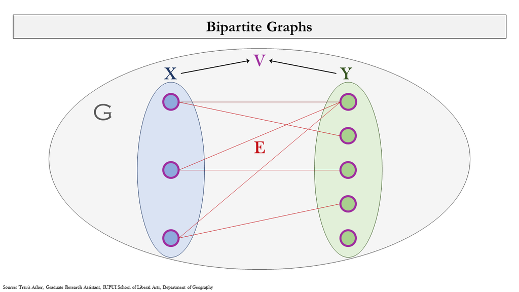

An example of a bipartite graph, $G=(V,E)$. The vertices $V$ are outlined in purple, the vertices of $X \subset V$ are filled in blue, the vertices $Y \subset V$ are filled in green, the edges $E$ are colored red, and the entire graph $G$ is shaded in grey.

At this point, we will define the concept of bipartite graphs to make use of later. Suppose $G=(V,E)$ is a graph;; that is, $G$ is an ordered pair $G=(V,E)$ comprised of $V$, a set of nodes or “vertices”, as well as $E$, a set of edges or “links”. For bipartite graphs, the only (fundamental) change is that we now divide the vertex set $V$ into two disjoint and independent subsets of vertices; that is,
$$X,Y : X \cap Y = \emptyset \text{ and } X \cup Y = V$$
Furthermore, an additional restriction is placed upon each edge element: if $e_k \in E$ is any edge of $G$, then $e_k$ connects an element in $X$ to an element in $Y$; that is,
$$\text{if } e_k = (v_{e_k},v_{e_k}') \in E \text{, then } v_{e_k} \in X \iff v_{e_k}' \in Y$$

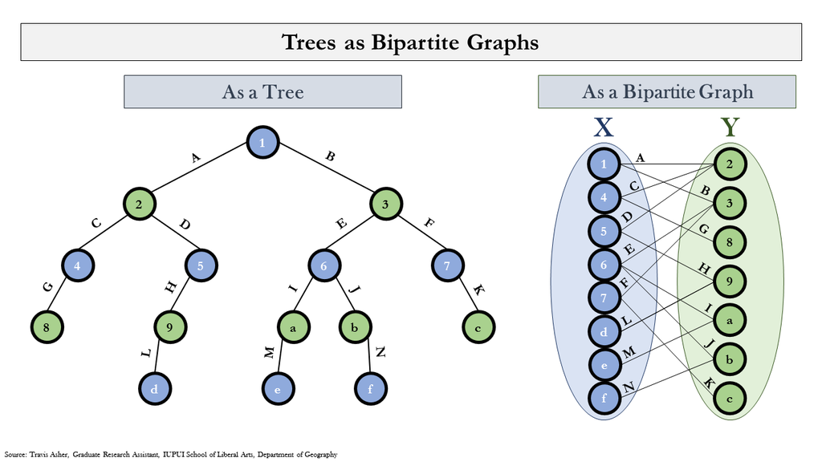

An example of the above proof applied to some rooted, binary tree, $T$. Blue nodes represent either even children of the root node “1” or the root node itself; green nodes represent odd children of the root node “1”. Numbers and lowercase letters denote vertices; capital letters denote edges.

A property of trees is that every tree is a bipartite graph. To prove this, begin with some rooted tree $T$ (if $T$ is not rooted, any arbitrarily selected node to serve as the root may be selected). We will adopt the notation “an **odd**/**even** child” to indicate a node that is an odd/even number of levels beneath the root node with respect to the hierarchy, respectively.

Define the set $X \subset V$ to be the collection of all such nodes within $V$ that are either even children of the root node or the root node itself; define the set $Y \subset V$ to be the collection of all such nodes within $V$ that are odd children of the root node. From these definitions, we have the first established property of bipartite graphs:
$$X \cap Y = \emptyset \text{ and } X \cup Y = V$$

Showing the additional property about edges is a simple task: consider any arbitrary edge
$$e_k=(v_{e_k},v_{e_k}') \in E \implies v_{e_k}, v_{e_k}' \in V$$
Because $T$ is an acyclic graph by definition, taking the convetion that the $0^{th}$ node of $T$ refers to the root node of $T$, it must be so that either

1. $\forall\ v_{e_k}$ in the $n^{th}$ hierarchy of $T$ where $n \in \Bbb N_0$, $v_{e_k}$ is the parent node to $v_{e_k}'$ which lies in the $(n+1)^{th}$ hierarchy of $T$
2. $\forall\ v_{e_k}$ in the $(n+1)^{th}$ hierarchy of $T$ where $n \in \Bbb N_0$, $v_{e_k}$ is the child node to $v_{e_k}'$ which lies in the $n^{th}$ hierarchy of $T$

For either case with $n \ne 0$,
$$n \in 2\Bbb N_0 \iff (n + 1) \notin 2 \Bbb N_0$$
meaning that if $v_{e_k}$ is in an even hierarchy of $T$, then $v_{e_k}'$ is in an odd hierarchy of $T$; the inverse statement holds as well. Hence,
$$v_{e_k} \in X \iff v_{e_k}' \in Y,\ \forall\ n \in \Bbb N^*$$
We can extend this to include the case where $n = 0$ by seeing that $v_{e_k}$ is the root node of $T$ (and hence is included in $X$) and that $v_{e_k}'$ is in an odd hierarchy of $T$, thus $v_{e_k}' \in Y$. The proof that $T$ is a bipartite graph follows from here.